# User Guide: PLSandO

### Option B: Using MBPCA

Even though the results are equivalent to the concatenated approach, providing the data as a list and using `algo = 'mbpca'` offers two advantages:

1. **Computational Efficiency:** In cases of **really high-dimensional data** (e.g., Omics data or high-resolution spectroscopy), handling individual datasets in a list is often faster and more memory-efficient. R can manage these smaller chunks more easily than a single, massive concatenated matrix.
2. **Block-level Diagnostics:** Using the MBPCA algorithm allows the tool to calculate the specific **contribution of each block** to the global explained variance (R^2). This is essential for understanding which data source is driving the model.

This is the recommended path for high-dimensional data or when block diagnostics are required.

```r
# Fit Multi-block PCA
mb_model = pca(X_blocks, algo = 'mbpca')
head(mb_model$Sscores)
```

```
##           p1         p2
## r1 -1.596039  0.3068551
## r2 -1.466550 -0.5050101
## r3 -1.666181 -0.2724254
## r4 -1.620483 -0.4510118
## r5 -1.684230  0.4239458
## r6 -1.462789  1.0217434
```

All previously presented plots are also allowed in MBPCA, but results are show at block and super level. An example will be showed with the visualization of the Scores.

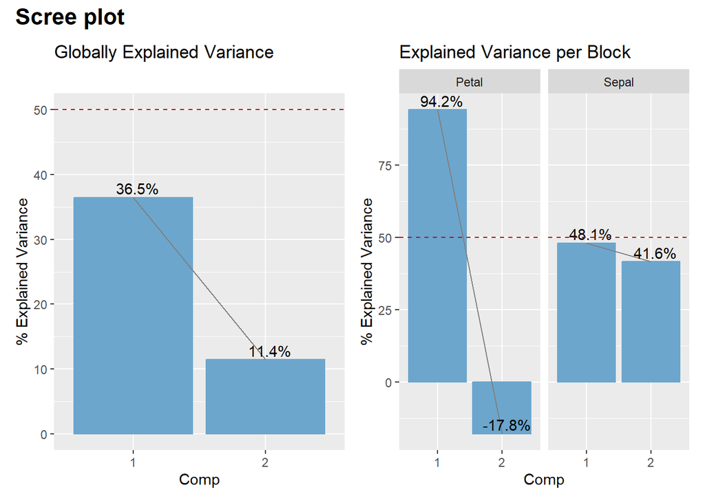

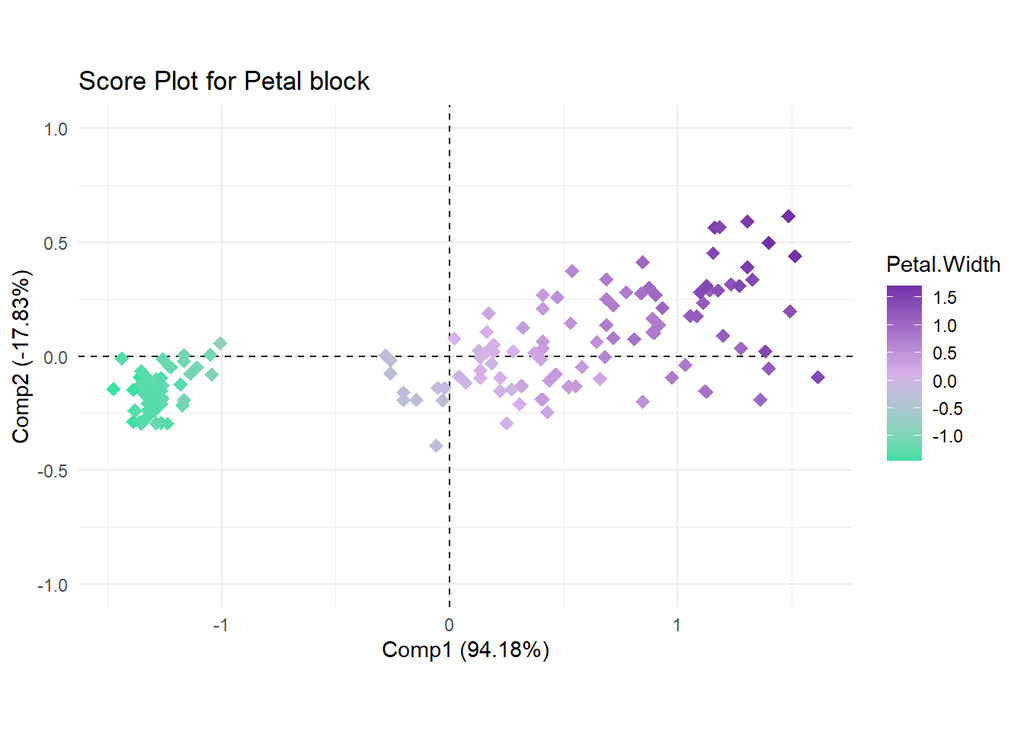

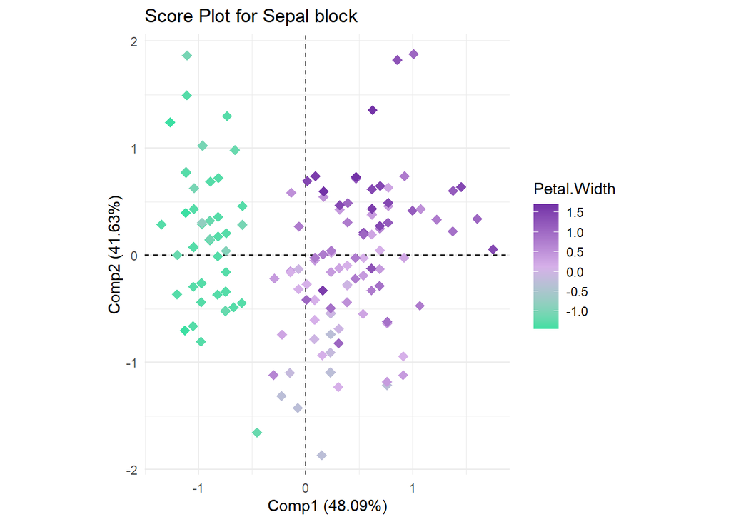

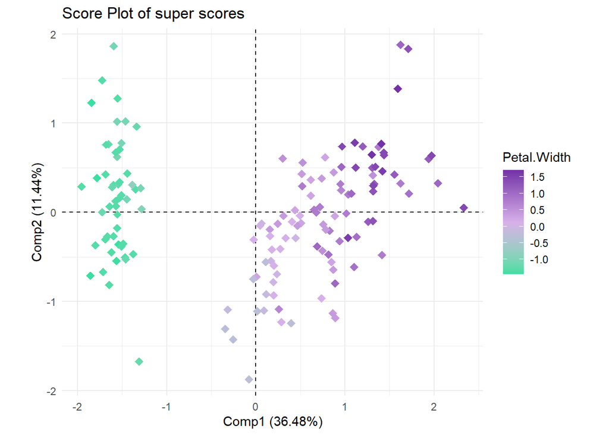

```r
# Score Plot for each block and the super level. Observations colores by the Petal.Width
pcaPlot(mb_model, type = 'scree')
pcaPlot(mb_model, type = 'scores', colBy = 'Petal.Width')
```

We can also look at the explained variance of the variables and the blocks to the model.

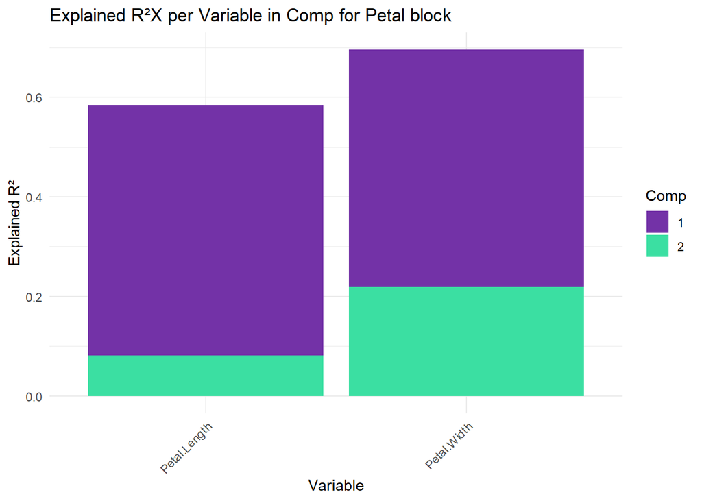

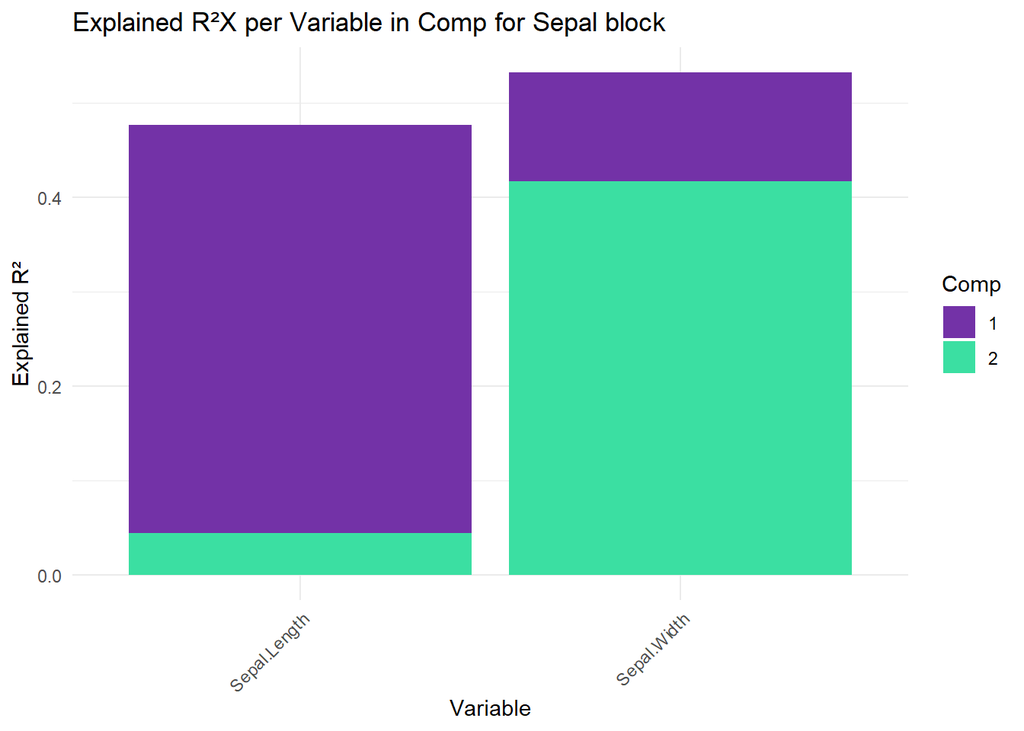

```r
# R2
pcaPlot(mb_model, type = 'R2')
```

# PLS

The `pls()` function allows modeling the relationship between a predictor matrix `X` and a response matrix `Y`. This is particularly useful when predictors are highly collinear or high-dimensional.

In line with PCA, the `Preparing()` function can be called prior to fitting a PLS model to handle essential matrix preprocessing. However, if the data is passed directly to the `pls()` function, the model automatically applies conservative default parameters to ensure the data is appropriately preprocessed for PLS modelling.

## Running Single-response PLS (PLS1)

Even if the dataset we have been using is not intended for this end, we will continue using the iris dataset to show case how to apply `pls()` function of `PLSandO` package. We will just take one of the variables as the response variable and we will try to model its relation with the rest of the variables.

A PLS model can easily be run by:

```r
# Define X and Y
X = iris[, 1:3, drop = FALSE]
Y = iris[, 4, drop = FALSE]

# Fit PLS model
mypls = pls(X, Y)
```

```
##
##  Running optimization:
##
##  Running optimization:
##
##  Running optimization:
##
##  Running optimization:
```

## Running Multi-response PLS (PLS2)

If Y contains multiple response variables, the package automatically performs PLS2. A PLS2 can be easily run by:

```r
# Define X and Y
X2 = iris[, 1:2, drop = FALSE]
Y2 = iris[, 3:4, drop = FALSE]

# Fit PLS model
mypls2 = pls(X2, Y2)
```

```
##
##  Running optimization:
##
##  Running optimization:
##
##  Running optimization:
```

## Results exploration

Once the model has been fitted, some brief summary can be explored to evaluate the performance of the model has been fitted. The `pls()` output includes information about the explained variance, the predictive ability through evaluated via cross-validation, and some other metrics that allowed to determine the optimal number of components and which can be used to assess the reliability of the model’s predictions.

These results can easily be evaluated via:

```r
mypls$summary
```

```
##   comp        R2X    cumR2X        R2Y    cumR2Y         Q2     cumQ2      RMSE
## 1    1 0.67280428 0.6728043 0.86125080 0.8612508 0.85722467 0.8572247 0.2870488
## 2    2 0.26913524 0.9419395 0.02191975 0.8831706 0.02131033 0.8785350 0.2647626
## 3    3 0.05806048 1.0000000 0.05467972 0.9378503 0.05504942 0.9335844 0.1957702
```

Results from the cross-validation can also be explored via:

```r
mypls$cv_results
```

## Results visualization

The `plsPlot()` function is a versatile wrapper for different plots for PLS results visualization.

First the code for visualizing a R2vsQ2 Plot is introduced:

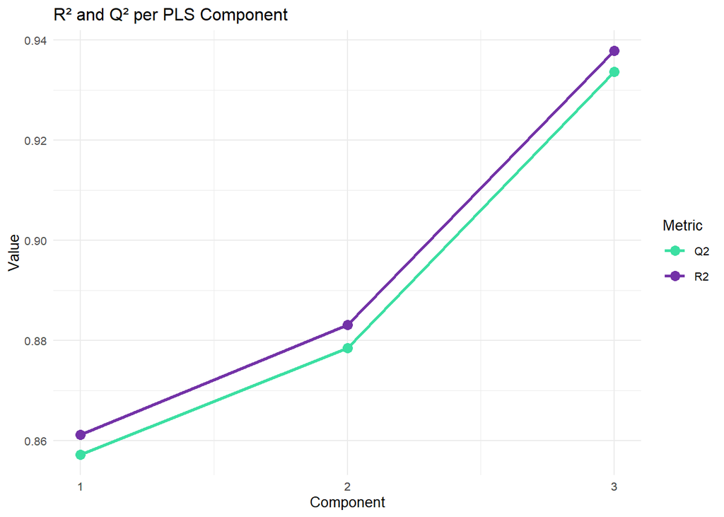

```r
# 1. R2vsQ2
plsPlot(mypls, type = 'R2vsQ2')
```

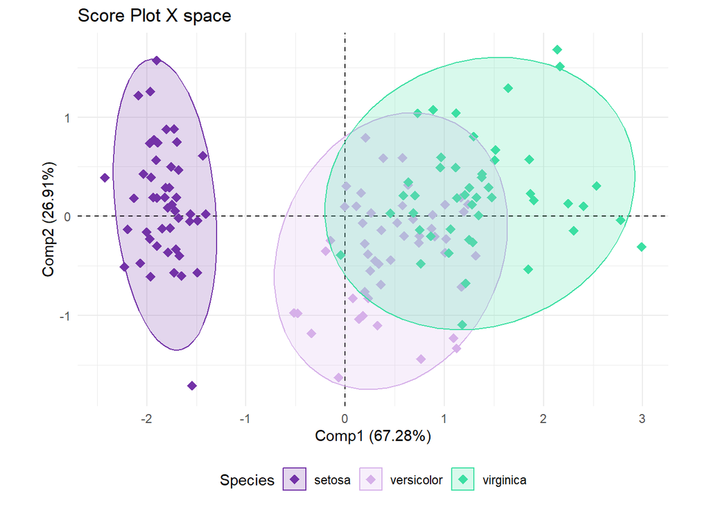

```r
# 2. Score Plot: Observations colored by Species
plsPlot(mypls, type = 'scoresX', colBy = as.data.frame(iris[, 5, drop = FALSE]), ellipses = TRUE)
```

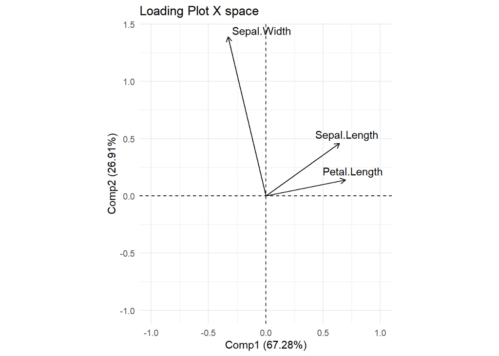

```r
# 3. Loading Plot
plsPlot(mypls, type = 'loadingsX')
```

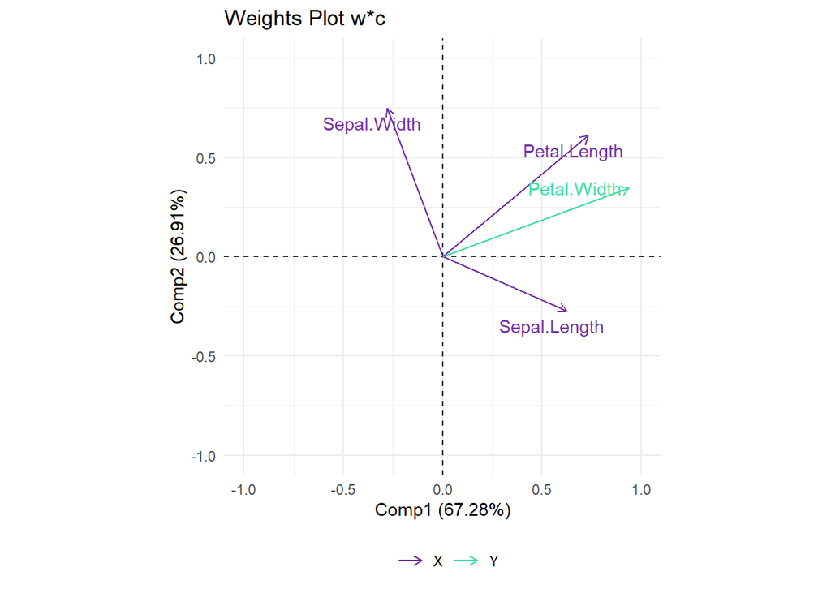

```r
# 4. Weight Plot
plsPlot(mypls, type = 'weights')
```

Additionally, PLSandO includes the option to create some plots to validate the PLS model created.

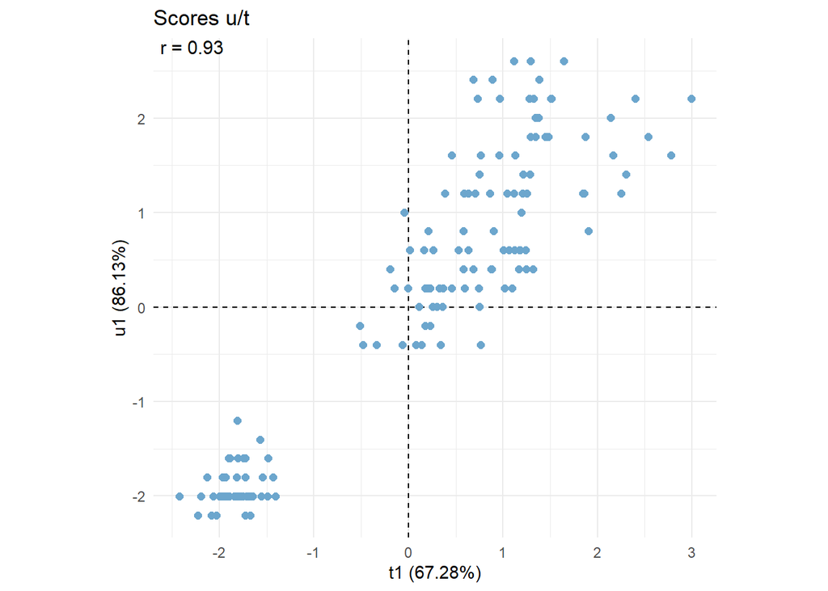

```r
# 5. Validating the internal relation between u and t scores
plsPlot(mypls, type = 'linearity')
```

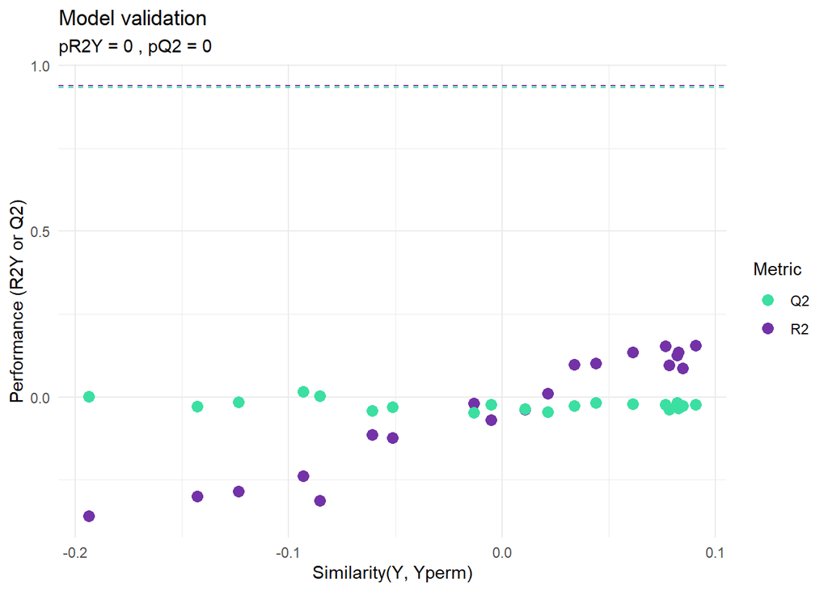

```r
# 6. Validating there are no overfitting problems
plsPlot(mypls, type = 'overfitting')
```

We can also analyze the explained variance of each variable per component via:

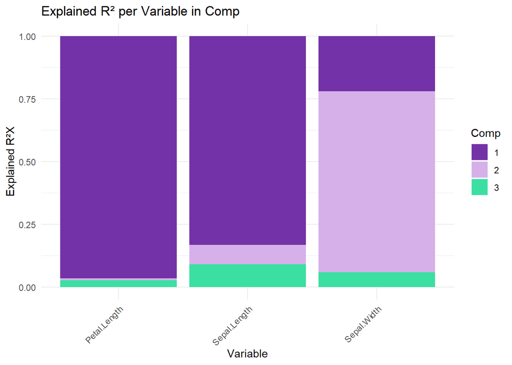

```r
#7. R2 per variable and component
plsPlot(mypls, type = 'R2X')
```

## Prediction

```r
# Splitting data for prediction
X_train = iris[1:125, 1:3, drop = FALSE]
Y_train = iris[1:125, 4, drop = FALSE]
X_new = iris[126:150, 1:3, drop = FALSE]

# Re-fitting and predicting
mypls_train = pls(X_train, Y_train)
```

```
##
##  Running optimization:
##
##  Running optimization:
##
##  Running optimization:
##
##  Running optimization:
```

```r
pred = predict(mypls_train, new = X_new)
```

[figure not shown]

```r
head(pred)
```

```
##     Petal.Width
## 126    2.076695
## 127    1.588825
## 128    1.700937
## 129    1.957774
## 130    1.934060
## 131    2.006423
```

We can also create extra plots also projecting new observations via:

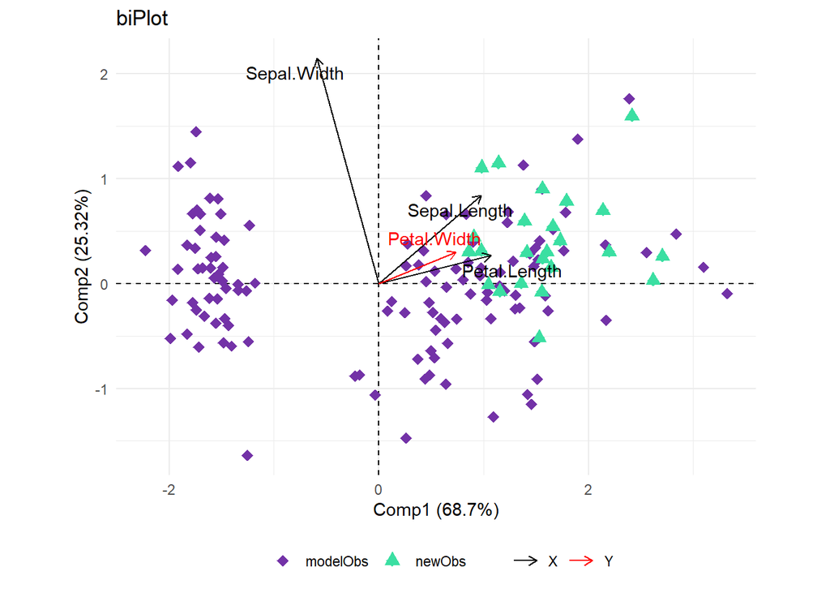

```r
# Biplot with new observations
plsPlot(mypls_train, type = 'biplot', newObs = X_new)
```

## Missing values

The package is robust to missing data, as PLS naturally handles NAs during training and prediction. Beyond this, the model could use the latent space structure to provide reliable imputations for missing values.

```r
# Introducing missing values
X[1,1] = NA
Xnew = iris[126:150,1:3,drop=FALSE]
Xnew[2,1] = NA

mypls_na = pls(X,Y)
```

```
##
##  Running optimization:
##
##  Running optimization:
##
##  Running optimization:
##
##  Running optimization:
```

```r
#Return X matrix without missing data using the latent structure
X_complete = imputeNipals(mypls_na, scaled = F)
head(X_complete)
```

```
##    Sepal.Length Sepal.Width Petal.Length
## r1     4.775041         3.5          1.4
## r2     4.900000         3.0          1.4
## r3     4.700000         3.2          1.3
## r4     4.600000         3.1          1.5
## r5     5.000000         3.6          1.4
## r6     5.400000         3.9          1.7
```

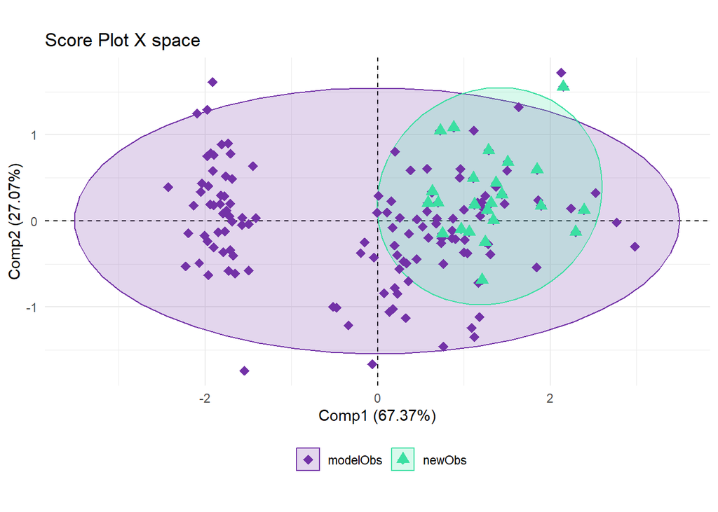

```
##     Petal.Width
## 126    2.126898
## 127    1.849768
## 128    1.732906
## 129    1.993449
## 130    1.977849
## 131    2.049491
```

```r
#Predict values even there are missing values
head(predict(mypls_na,Xnew))
```

## Outlier detection

PLSandO also provides functionalities to identify influential outliers.

```r
# Outlier detection and contribution analysis
out = plsOutliers(mypls)
plsOutlierContrib(mypls, outliers = out)
```

```
## There are no severe outliers in the data or they were not computed.
## There are 3 moderate outliers in the data.
```

```
## $contribT2
## NULL
##
## $contribRSS
##      Sepal.Length Sepal.Width Petal.Length
## r106     68.89952  -0.4784689     30.62201
## r119     59.01639   0.0000000     40.98361
## r136     68.48989   1.0701546     30.43995
```

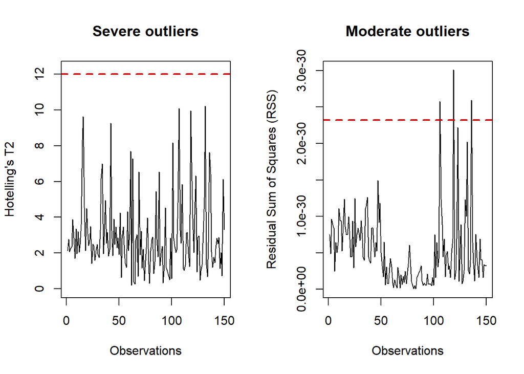

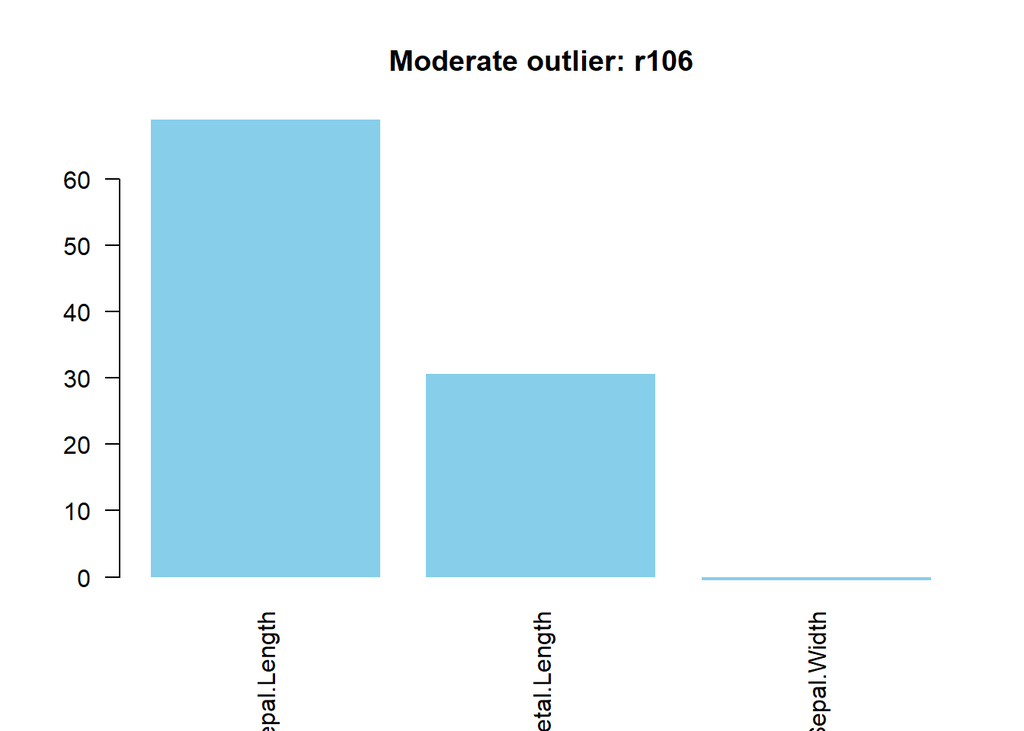

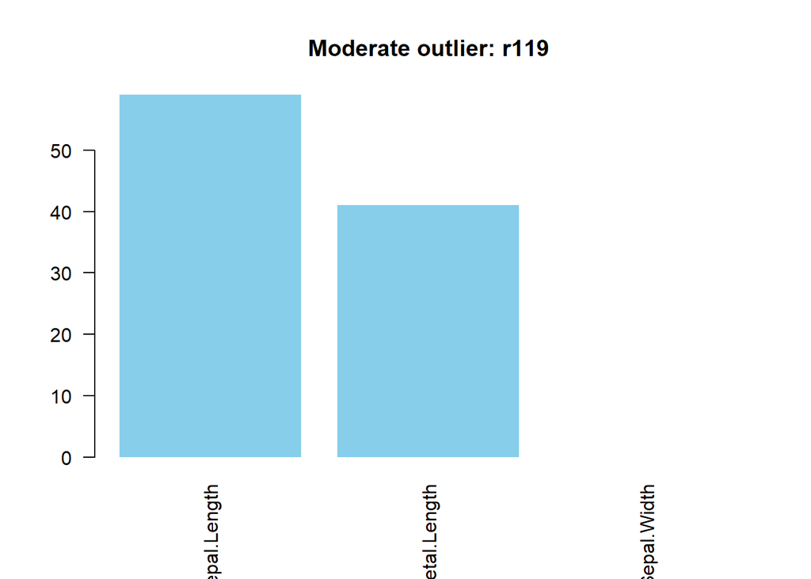

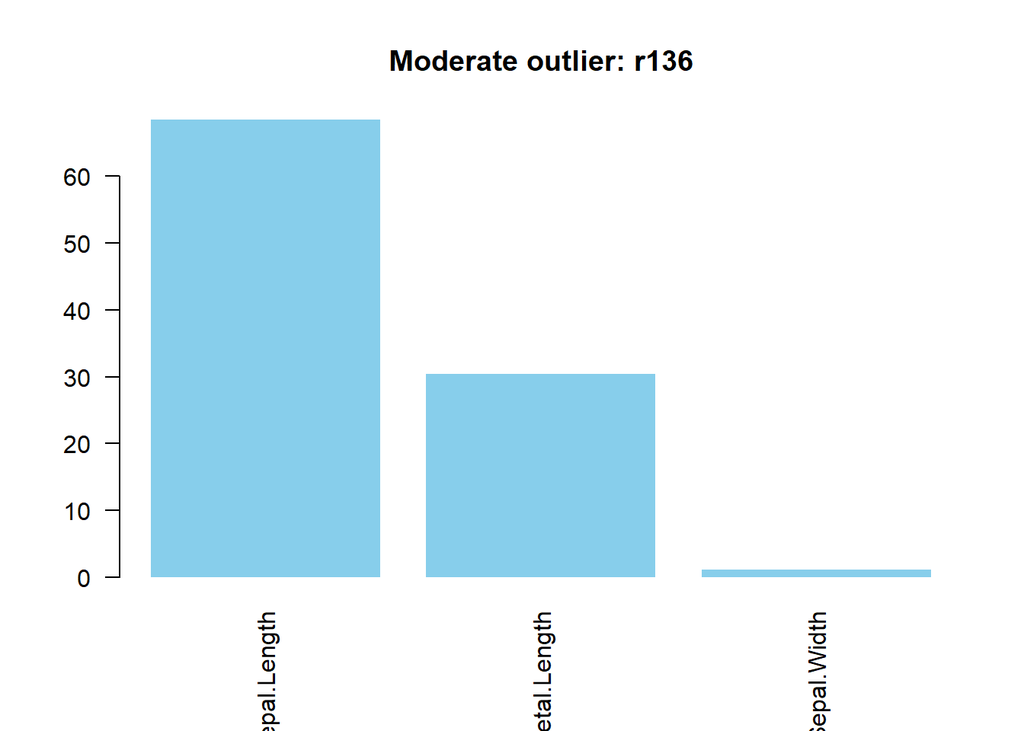

## Variable selection

For variable selection, the `plsVarSel()` function identifies the most influential predictors in your model, allowing you to simplify your model and focus on the key variables that drive the model. It supports the variable selection according to different criteria: by Variable Importance in Projection (VIP), by the significant Multivariate Correlation (sMC), p-values obtained from Jack-Kniffing or by Permutation sampling.

```r
# Summary of models variables and Jack-Knife resampling results
mypls$coefficients_summary
```

```
##              coefficient       pValJK      LCI_JK    UCI_JK
## Sepal.Length -0.17163002 2.149239e-01 -0.44446094 0.1012009
## Sepal.Width   0.09712345 1.813746e-01 -0.04604361 0.2402905
## Petal.Length  0.92516300 7.459678e-07  0.57770503 1.2726210
```

```r
# Identify key predictors using Permutation testing
plsVarSel(mypls, type = 'Perm')
```

```
##              pValPerm
## Petal.Length        0
```

```r
# Identify key predictors using VIP scores
plsVarSel(mypls, type = 'VIP')
```

```
##                   VIP
## Petal.Length 1.234772
## Sepal.Length 1.078044
```

[figure not shown]

[figure not shown]